# Predicting the Star Ratings of Amazon Reviews using Neural Networks

## 1. Executive Summary

Text Classification is of prime importance in Machine Learning. One of the major concens using text Data for classification is that it often involves operating with highly sparse data. What makes these problems unique and somewhat difficult to handle? In ML 1.0 we found out that Logistic Regression was the best method to do text classification and we achieved a test accuracy of around 72%. The simplest neural networks - the Multilayer Perceptrons (MLP) have the same objective function as the Logistic Regression. Does that mean that MLP's inherently work well for text classification? This project helps to unearth some aspects regarding the same. At the end, we would have a clear cut mental model as to how to tackle sparse data more so text classification problems in Machine Learning.

**Problem Statement:**

> > " **Identify the viability of Multi-layer Perceptrons in handling problems related to text classification"** </font>

**Data Description:**

Over 1000 reviews of Amazon products with their corresponding star ratings

**Summary of Results and Conclusion**

## 2. Methodology

This entire project was executed according to the below guidelines:

- **Data set scraped from Amazon.com**
  - Identification of relevant features (here reviews and star rating)
  - Pre - processing the reviews(stop words removal, stemming , lemmatizing etc.)
- **Determination of Optimal Machine Learning 2.0 Classification Algorithms (trying only MLPs here)**
  - First apply the Logistic Regression Model to create our Baseline Accuracy
  - Now apply different combinations of MLP architectures to beat our baseline accuracy of Logistic Regression
- **Conclusion**

### Loading the required libraries

```python
import pandas as pd
import numpy as np
import sqlite3
from sklearn.manifold import TSNE
import nltk
from nltk.stem import PorterStemmer
from nltk.stem.wordnet import WordNetLemmatizer
from gensim.models import Word2Vec
from sklearn.decomposition import TruncatedSVD
import pandas as pd
import numpy as np
import matplotlib.pyplot as plt
from sklearn.preprocessing import MinMaxScaler
from sklearn.preprocessing import StandardScaler
from sklearn.neighbors import KNeighborsClassifier
from sklearn.linear_model import LogisticRegression
from sklearn.svm import LinearSVC
from sklearn.svm import SVC
from sklearn.model_selection import train_test_split
from tqdm.autonotebook import tqdm
from tqdm import trange
from time import sleep
import pandas as pd
import numpy as np
import matplotlib.pyplot as plt
from sklearn.preprocessing import MinMaxScaler
from sklearn.preprocessing import StandardScaler
from sklearn.neighbors import KNeighborsClassifier
from sklearn.linear_model import LogisticRegression
from sklearn.tree import DecisionTreeClassifier
from sklearn.svm import LinearSVC
from sklearn.svm import SVC
from sklearn.model_selection import train_test_split
from tqdm.autonotebook import tqdm
from tqdm import trange
from time import sleep
from sklearn.model_selection import learning_curve, GridSearchCV
import warnings
warnings.filterwarnings('ignore')
# %%time
import os
os.environ["PATH"] += os.pathsep + 'C:/Program Files (x86)/release/bin'
from sklearn.ensemble import RandomForestClassifier
from sklearn.ensemble import GradientBoostingClassifier
from ann_visualizer.visualize import ann_viz;
```

```python
from scipy.spatial.distance import euclidean, cityblock
import re
from collections import Counter
from wordcloud import STOPWORDS, WordCloud
%matplotlib inline
import matplotlib.pyplot as plt
from sklearn.feature_extraction.text import TfidfVectorizer
import seaborn as sns
from sklearn.feature_extraction.text import CountVectorizer
```

### Reading Data from the DataBase

- Data has been scraped from Amazon.com and stored in the Sql Lite Data base, however in the interest of reproducibility, I have filtered top 1000 reviews in a csv file and am reading from it

```python
# conn = sqlite3.connect('database.sqlite')
```

```python
#amazn1 = pd.read_sql(""" SELECT * from Reviews""",conn )
amazn1 = pd.read_csv('Aditya.csv')
```

```python
amazn1=amazn1.iloc[:1000,:] # Selecting only the 1000 reviews
```

### Feature Engineering :

- Generating a new feature 'final_score' such that if Amazon rating is more than 4 it's 1 (high) else 0 (low)
- The above operation converts our problem to a binary classification problem

```python
amazn1['final_score'] = amazn1.Score.apply(lambda x : 1 if x>4 else 0)
```

```python
amazn1['final_score'].value_counts()
```

```
1    642
0    358
Name: final_score, dtype: int64
```

```python
amazn1.final_score.value_counts()
```

```
1    642
0    358
Name: final_score, dtype: int64
```

```python
amazn1.shape
```

```
(1000, 11)
```

```
Population per class:      0
1  642
0  358

1.25 * Proportion Chance Criterion: 67.541%
```

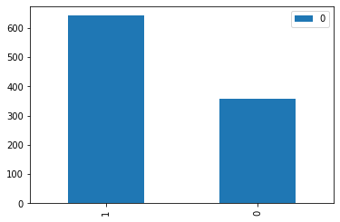

```python
import numpy as np
from collections import Counter
state_counts = Counter(amazn1['final_score'])
df_state = pd.DataFrame.from_dict(state_counts, orient='index')
df_state.plot(kind='bar')

num=(df_state[0]/df_state[0].sum())**2
print("Population per class: {}\n".format(df_state))
print("1.25 * Proportion Chance Criterion: {}%".format(1.25*100*num.sum()))
```

**From above, we see that 1.25* PCC is 67.54%, Our classifier needs to beat this to be deemed a good model**

```python
amazn = amazn1.copy()
```

### Sample Text Document

```python
amazn.Text[0]
```

```
'I have bought several of the Vitality canned dog food products and have found them all to be of good quality. The product looks more like a stew than a processed meat and it smells better. My Labrador is finicky and she appreciates this product better than  most.'
```

### Basic Text Cleaning and Preprocessing

- Stop words removed
- HTML, HTTP tags removed
- Stemming
- Lemmatizing
- Lowercased

```python
stop_words= set(['br', 'the', 'i', 'me', 'my', 'myself', 'we', 'our', 'ours', 'ourselves', 'you', "you're", "you've",\
            "you'll", "you'd", 'your', 'yours', 'yourself', 'yourselves', 'he', 'him', 'his', 'himself', \
            'she', "she's", 'her', 'hers', 'herself', 'it', "it's", 'its', 'itself', 'they', 'them', 'their',\
            'theirs', 'themselves', 'what', 'which', 'who', 'whom', 'this', 'that', "that'll", 'these', 'those', \
            'am', 'is', 'are', 'was', 'were', 'be', 'been', 'being', 'have', 'has', 'had', 'having', 'do', 'does', \
            'did', 'doing', 'a', 'an', 'the', 'and', 'but', 'if', 'or', 'because', 'as', 'until', 'while', 'of', \
            'at', 'by', 'for', 'with', 'about', 'against', 'between', 'into', 'through', 'during', 'before', 'after',\
            'above', 'below', 'to', 'from', 'up', 'down', 'in', 'out', 'on', 'off', 'over', 'under', 'again', 'further',\
            'then', 'once', 'here', 'there', 'when', 'where', 'why', 'how', 'all', 'any', 'both', 'each', 'few', 'more',\
            'most', 'other', 'some', 'such', 'only', 'own', 'same', 'so', 'than', 'too', 'very', \
            's', 't', 'can', 'will', 'just', 'don', "don't", 'should', "should've", 'now', 'd', 'll', 'm', 'o', 're', \
            've', 'y', 'ain', 'aren', "aren't", 'couldn', "couldn't", 'didn', "didn't", 'doesn', "doesn't", 'hadn',\
            "hadn't", 'hasn', "hasn't", 'haven', "haven't", 'isn', "isn't", 'ma', 'mightn', "mightn't", 'mustn',\
            "mustn't", 'needn', "needn't", 'shan', "shan't", 'shouldn', "shouldn't", 'wasn', "wasn't", 'weren', "weren't", \
            'won', "won't", 'wouldn', "wouldn't"])
```

```python
nltk.download('wordnet')
```

```
True
```

```python
lemmatizer = WordNetLemmatizer()
ps = PorterStemmer()
```

```python
processed_reviews=[]
cnt=0
for text in amazn.Text:
    text = re.sub(r'[^a-zA-Z0-9\s]*','',text)
    text = re.sub(r'htt[sp]://','',text).strip()
    text = ' '.join(e.lower() for e in text.split() if e.lower() not in stop_words and len(e.lower())>2)
    text = lemmatizer.lemmatize(text)
    text = ps.stem(text)
    processed_reviews.append(text)
```

### Plotting a word cloud for getting a feel of our data

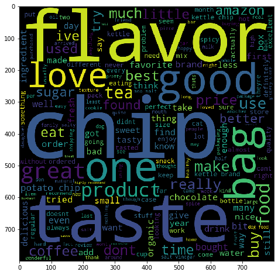

```python
fig,ax = plt.subplots(1,1,figsize=(14,8))
wordcloud = WordCloud(width=800, height=800,
                background_color='black',
                min_font_size = 10).generate(' '.join((processed_reviews)))
ax.imshow(wordcloud)
```

## Tf-IDF Implementation of our processed reviews

```python
tf = TfidfVectorizer(stop_words='english',min_df=0.01)
tf_vect = tf.fit_transform(processed_reviews)
```

```python
tf_vect.shape
```

```
(1000, 544)
```

#### We notice that our Data Matrix is sparse

```python
type(tf_vect)
```

```
scipy.sparse.csr.csr_matrix
```

```python
len(tf.vocabulary_.keys())
```

```
544
```

```python
tf.get_feature_names()[:10]
```

```
['100',
 'able',
 'absolutely',
 'actually',
 'add',
 'added',
 'addicted',
 'aftertaste',
 'agave',
 'ago']
```

**X and y for tfidf**

```python
X_tfidf = tf_vect.toarray()
y_tfidf = amazn.final_score
```

### Plotting the TSNE Plot our Tf-idf data matrix

```python
tsne = TSNE(random_state=1208).fit_transform(tf_vect.todense())
```

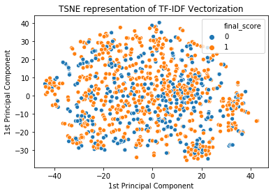

```python
sns.scatterplot(tsne[:,0],tsne[:,1],hue=amazn.final_score)
plt.xlabel('1st Principal Component')
plt.ylabel('1st Principal Component')
plt.title('TSNE representation of TF-IDF Vectorization')
```

We can see that just the 2 principal components explain very little variance hence the TSNE plots of the data is not very representative of the pattern in the data set.

##### Visualizing the Sparsity of our Data Matrix, for getting a better intuition of the results that follow

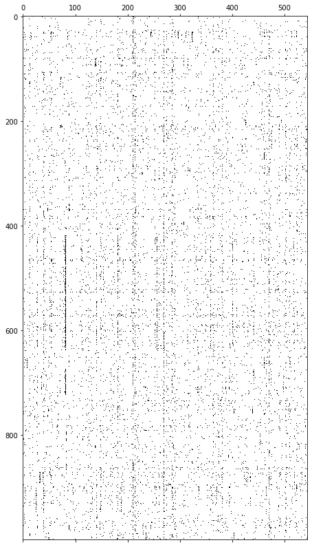

```python
plt.figure(figsize=(14,14))
plt.spy(X_tfidf)
plt.savefig('Sparse.png')
```

## ML 1.0 Logistic Regression Algorithm Applied

```python
Number_trials=1
def train_logistic(X, y, reg, scale=None):
    """
    Implements Logistic Regression

    Parameters:
    --------------
    X - Cleaned Data
    y - Target
    reg - Regularization Parameter (l1/l2)
    scale - Default is None. Specify scaler e.g StandardScaler or MinMaxScaler

    """
    C = [1e-8, 1e-4, 1e-3, 1e-2, 0.1, 0.2,0.4, 0.75, 1, 1.5, 3, 5, 10, 15,  20, 100, 300, 1000, 5000]

    score_train = []
    score_test = []
    weighted_coefs=[]
    print('Logistic - {}'.format(reg))
    for seed in tqdm(range(Number_trials)):
        training_accuracy = []
        test_accuracy = []
        X_train, X_test, y_train, y_test = train_test_split(X, y, test_size=0.25, random_state=seed)
        if scale:
            X_train = scale.fit_transform(X_train)
            X_test = scale.transform(X_test)
        for alpha_run in C:
            lr = LogisticRegression(C=alpha_run, penalty=reg).fit(X_train, y_train)
            training_accuracy.append(lr.score(X_train, y_train))
            test_accuracy.append(lr.score(X_test, y_test))
            coefs=lr.coef_
            weighted_coefs.append(coefs) #append all the computed coefficients per trial

        score_train.append(training_accuracy)
        score_test.append(test_accuracy)

    mean_coefs=np.mean(weighted_coefs, axis=0) #get the mean of the weighted coefficients over all the trials
    #print(mean_coefs)
    score = np.mean(score_test, axis=0)
    #return score.shape
    #coefs = lr.coef_
    #return C value, accuracy, column/feature name
#     top_predictor='NA'
    if (np.unique(y).size > 2):
        class_coeff={}
        C_max=C[np.argmax(score)]
        lr = LogisticRegression(C=C_max,penalty=reg).fit(X_train, y_train)
        coeff = lr.coef_
        class1 = lr.classes_
        for c,i in zip(class1,range(coeff.shape[0])):
#             print(coeff[i])
            class_coeff[c] = X.columns[np.argmax(coeff[i])]


    if (np.unique(y).size == 2):
        top_predictor=X.columns[np.argmax(np.abs(mean_coefs))]
        abs_mean_coefs = np.abs(mean_coefs[0,:])
        coefs_count = len(abs_mean_coefs)
        fig, ax = plt.subplots(figsize=(3,5))
        ax.barh(np.arange(coefs_count), sorted(abs_mean_coefs))
        #ax.barh(np.arange(coefs_count), mean_coefs[0, np.argsort(abs_mean_coefs)])
        ax.set_yticks(np.arange(coefs_count))
        ax.set_yticklabels(X.columns[np.argsort(abs_mean_coefs)])
        ax.set_title('Logistic Regression Feature Importance {0} regularized'.format(reg))
        #     print('Scaling used is: ', scale)
        return ['Logistic ({0})'.format(reg), np.amax(score), \
                'C = {0}'.format(C[np.argmax(score)]), top_predictor]
    else:
        return ['Logistic ({0})'.format(reg), np.amax(score), \
                'C = {0}'.format(C[np.argmax(score)]), class_coeff]
```

```python
import warnings
warnings.filterwarnings('ignore')

X=X_tfidf
y=y_tfidf

X = pd.DataFrame(X)

# a = train_knn(X,y,scale=None)
# # print(a)
b = train_logistic(X,y,reg='l2',scale=None)
# print(b)
c = train_logistic(X,y,reg='l1',scale=None)
# print(c)
#d = train_svm(X,y,reg='l2',scale=None)
# print(d)
#e = train_svm(X,y,reg='l1',scale=None)
# # print(e)
# f = train_Nsvm(X,y,reg='rbf',scale=None)
# # print(f)
# g = train_Nsvm_poly(X,y,reg='poly',scale=None)

# h = train_DecisonTree(X,y,scale=None,draw_tree=True)

# i = train_RandomForest(X,y,scale=None,draw_tree=True)
# j = train_GradientBoosting(X,y,scale=None,draw_tree=True)

cols = ['Machine Learning Method', 'Test Accuracy', 'Best Parameter', 'Top Predictor Variable']
df2 = pd.DataFrame(columns=cols)
pd.set_option('display.max_colwidth', -1)
# df2.loc[0] = a
df2.loc[1] = b
df2.loc[2] = c
# df2.loc[3] = d
# df2.loc[4] = e
# df2.loc[5] = f
# df2.loc[6] = g
# df2.loc[7] = h
# df2.loc[8] = i
# df2.loc[9] = j
# df2.to_csv('Data.csv')
```

```python
df2.drop('Top Predictor Variable',axis=1)
```

|  | Machine Learning Method | Test Accuracy | Best Parameter |
| --- | --- | --- | --- |
| 1 | Logistic (l2) | 0.724 | C = 0.75 |
| 2 | Logistic (l1) | 0.696 | C = 1.5 |

**We see that our Baseline Accuracy with Logistic Regression is 72.4%**

## ML 2.0 Let's start building our MLP model

### Model 1 : Simple MLP with 1 hidden layer, 1 output layer

```python
X=X_tfidf
y=y_tfidf
```

```python
X_train, X_test, y_train, y_test = train_test_split(X, y, test_size=0.25, random_state=42)
```

```python
#https://machinelearningmastery.com/tutorial-first-neural-network-python-keras/
from keras.models import Sequential
from keras import layers

input_dim = X_train.shape[1]  # Number of features

model = Sequential()
model.add(layers.Dense(50, input_dim=input_dim, activation='sigmoid'))
model.add(layers.Dense(1, activation='sigmoid'))
```

```python
model.compile(loss='binary_crossentropy',
              optimizer='adam',
              metrics=['accuracy'])
model.summary()
```

```
_________________________________________________________________
Layer (type)                 Output Shape              Param #
=================================================================
dense_3 (Dense)              (None, 50)                27250
_________________________________________________________________
dense_4 (Dense)              (None, 1)                 51
=================================================================
Total params: 27,301
Trainable params: 27,301
Non-trainable params: 0
_________________________________________________________________
```

#### Visualizing our Model

```python
ann_viz(model, title="Model A : 1 Hidden Layer and 1 Output Layer",filename='ModelA.gv')
```

[figure not shown]

```python
history=model.fit(X_train, y_train,
                    epochs=100,
                    verbose=False,
                   validation_data=(X_test, y_test),
                   batch_size=100)
```

```python
loss, accuracy = model.evaluate(X_train, y_train, verbose=False)
print("Training Accuracy: {:.4f}".format(accuracy))
loss, accuracy = model.evaluate(X_test, y_test, verbose=False)
print("Testing Accuracy:  {:.4f}".format(accuracy))
```

```
Training Accuracy: 0.9680
Testing Accuracy:  0.6880
```

**We see that our Accuracy is 68%, we are close to our baseline accuracy of 72.4%, Let's visualize our accuracy and loss plots**

```python
import matplotlib.pyplot as plt
plt.style.use('ggplot')

def plot_history(history):
    acc = history.history['acc']
    val_acc = history.history['val_acc']
    loss = history.history['loss']
    val_loss = history.history['val_loss']
    x = range(1, len(acc) + 1)

    plt.figure(figsize=(12, 5))
    plt.subplot(1, 2, 1)
    plt.plot(x, acc, 'b', label='Training acc')
    plt.plot(x, val_acc, 'r', label='Test acc')
    plt.title('Training and Test accuracy')
    plt.legend()
    plt.subplot(1, 2, 2)
    plt.plot(x, loss, 'b', label='Training loss')
    plt.plot(x, val_loss, 'r', label='Test loss')
    plt.title('Training and Test loss')
    plt.xlabel('Number of epochs')

    plt.legend()
```

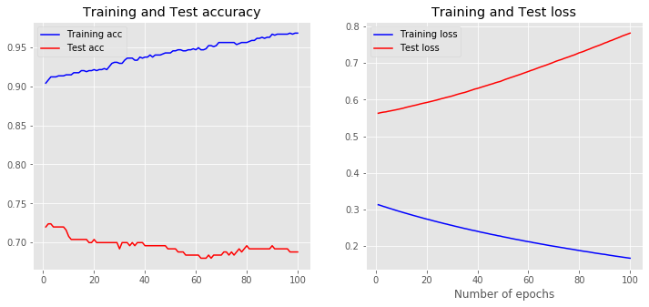

```python
plot_history(history)
```

### Model 2 : Simple MLP with 1 hidden layer, 1 output layer, Adding a Dropout layer with a dropout rate of 20%

```python
from keras.models import Sequential
from keras import layers
from keras.layers import Dropout

input_dim = X_train.shape[1]  # Number of features

model = Sequential()
model.add(layers.Dense(60, input_dim=input_dim, activation='sigmoid'))
model.add(Dropout(0.2))
model.add(layers.Dense(1, activation='sigmoid'))
# model1.add(Dropout(0.2))
```

```python
model.compile(loss='binary_crossentropy',
              optimizer='adam',
              metrics=['accuracy'])
model.summary()
history = model.fit(X_train, y_train,
                    epochs=100,
                    verbose=False,
                   validation_data=(X_test, y_test),
                   batch_size=100)
```

```
_________________________________________________________________
Layer (type)                 Output Shape              Param #
=================================================================
dense_15 (Dense)             (None, 60)                32700
_________________________________________________________________
dropout_6 (Dropout)          (None, 60)                0
_________________________________________________________________
dense_16 (Dense)             (None, 1)                 61
=================================================================
Total params: 32,761
Trainable params: 32,761
Non-trainable params: 0
_________________________________________________________________
```

#### Visualizing our Model

```python
ann_viz(model, title="Model B : 1 Hidden Layer and 1 Output Layer with Drop Outb",filename='ModelA.gv')
```

[figure not shown]

```python
loss, accuracy = model.evaluate(X_train, y_train, verbose=False)
print("Training Accuracy: {:.4f}".format(accuracy))
loss, accuracy = model.evaluate(X_test, y_test, verbose=False)
print("Testing Accuracy:  {:.4f}".format(accuracy))
```

```
Training Accuracy: 0.8773
Testing Accuracy:  0.7360
```

### Voila!! Our test accuracy is 73.6% hence, we were able to beat our baseline accuracy of 72.4% with a relatively simple MLP

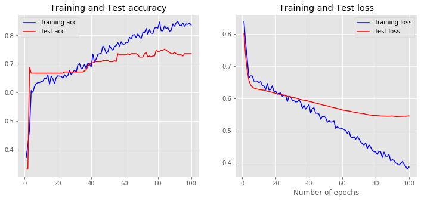

```python
plot_history(history)
```

## Discussion of Results

[figure not shown]

## Summary and Conclusion

### Bonus Learnings:

- **ann_viz** package is used to create beautiful vizualizations for our Neural Networks

> > "**With a Classification Model Accuracy of 73.6%, we were able to predict the star rating of an Amazon product Review and have successfully created a mental model to deal with problems related to text classification**"